# Final Paper

STOR 320.01 Group 11

April 28, 2025

# INTRODUCTION

As students living in North Carolina, understanding local traffic safety is particularly important to us. Cary, NC, has experienced rapid population growth in recent years due to a great public education system, proximity to a mid-sized airport, and recent amenity development. The growth brings more cars per household, an influx of drivers learning new local roads, increased traffic during rush hours, and more pedestrians and cyclists. This combination brings the perfect storm of heightened accident conditions for the city.

Car accidents not only threaten the safety of a community but also impose significant financial burdens. These crashes usually go hand-in-hand with property damage and medical bills — costs that fall directly on the resident, which could otherwise be used in Cary’s economy. Reducing these expense occurrences would improve the overall quality of life in the area. Beyond personal impacts, accident hotspots put a strain on public goods, requiring the city to allocate more of its budget toward first responders instead of bettering the infrastructure or the community. By increasing traffic safety through calculated road improvements, Cary could initiate a positive feedback loop of lower costs leading to greater communal investment and a stronger city in the long term.

Our group decided to analyze real crash data from Cary, so we can provide valuable insights into where crashes are most likely to occur and what factors contribute to more severe outcomes. We hypothesized that within the data, we can make conclusions that certain combinations of those factors will lead to a pattern of crash frequency and severity. These insights could help inform city officials, engineers, and residents alike on how to make Cary’s streets safer for everyone. The goal of our analysis is to explore two important questions:

**Question 1: Where are crashes most concentrated within Cary, NC, and how do roadway characteristics (such as road type, surface condition, and lighting) predict crash severity?**

**Question 2: How does the time of day affect crash frequency at a crash hotspot in Cary, NC? How does time of day predict crash frequency?**

Our group’s definition of severity falls into two categories that will be defined more in depth later in the paper–a numeric index and a binary category. Our numeric index assigns different weights to number of injuries and the number of deaths in a crash, normalized by the number of people involved to get a per-person crash severity. Our binary variable classifies a crash as severe if injuries or fatalities occurred, and as property damage (PDO) if none occurred. Understanding spatial crash patterns and their severity can help prioritize infrastructure improvements. By highlighting certain “at risk” areas, the city can look into changing traffic patterns and road designs to minimize the potential for driver injury. Identifying temporal trends can guide law enforcement and public safety campaigns – if crashes are more frequent or more severe at certain times, the city could adjust traffic laws, lighting, or police patrols accordingly. By answering these two questions, we hope to provide recommendations that could reduce future crash rates and enhance traffic safety in our local community.

# DATA

Our primary dataset was provided by the Town of Cary, NC, and compiled through public records of traffic incidents using the National Incident Based Reporting System (NIBRS). It contains crash information from the past five years through 2025 and is continuously updated as new reports are filed. Each observation represents a single crash event within Cary’s town limits, detailing a wide range of variables such as crash location (latitude and longitude), time and date, roadway conditions, weather, lighting, traffic control, vehicle types involved, and the severity of injuries or fatalities.

To investigate our questions, we primarily focus on certain variables within the dataset. Key variables were **Latitude and Longitude** (used to identify the exact crash location to five decimal points of accuracy), **Crash date and time** (indicates when the crash was reported), **Road Surface, Road Class, Traffic Control, and Light Condition**. Lighting condition specifies if the crash happened in daylight or the dark with or without artificial lights. Traffic control specifies if there were any traffic signals or construction at the location of the crash. Road surface is a character variable, describing the characteristic of the road where the crash occurs. Similarly, road class is also character variable, dictating the type of road the crash took place on. We also included **Fatalities and Possible Injuries**, used to define crash severity. In total, after cleaning and filtering for complete observations, our analysis included approximately 22,116 crash events across Cary.

Summary of Key Crash Dataset Variables

| Metric | Value |
| --- | --- |
| Total Crashes | 22116 |
| Unique Locations | 20451 |
| Latitude Range | -78.858 to 78.3214 |
| Longitude Range | -87.7826 to 78.9706 |
| Mean Severity Index | 0.52 |
| Max Severity Index | 53.23 |
| Min Injuries Reported | 0 |
| Max Injuries Reported | 14 |
| Max Fatalities | 2 |
| Most Common Road Class | [‘STATE SECONDARY ROUTE’] |
| Most Common Road Surface | SMOOTH ASPHALT |
| Most Common Lighting Condition | DAYLIGHT |
| Most Common Traffic Control | NO CONTROL PRESENT |

We also created a binary classification of severity, where a crash is considered severe if a fatality or injury occurred and non-severe if it was only property damage (PDO). This type of classification is also well-described in traffic safety literature, as fatal and severe injury crashes are more costly to society than property damage only (PDO) crashes. This approach allowed us to examine the consistency of predictors across two different measures of severity. However, as the distributions of our severity measures show, fatalities and injuries are generally infrequent. The distributions are heavily right-skewed, with the majority of crashes being classed as non-severe (PDO) or with a low numeric index. This imbalanced distribution limits the predictive capabilities of our model for crash severity, as it is difficult to predict extreme outliers reliably.

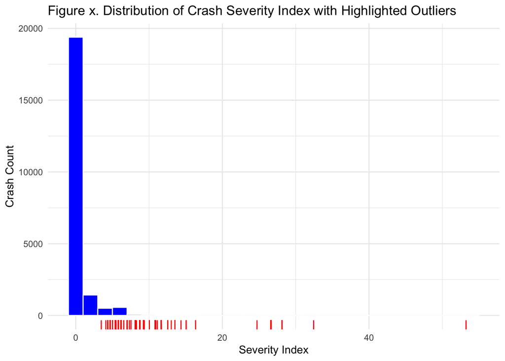

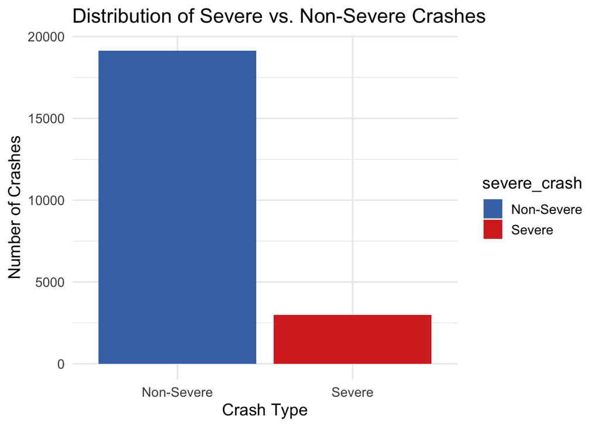

During data cleaning, we addressed missing values in the number of passengers and pedestrians fields, which were sometimes left blank in the original dataset. To standardize calculations, we assumed that each vehicle involved in a crash contributed exactly one driver. We created a new variable, number of drivers, defined as equal to the number of vehicles recorded per crash. Total people involved in a crash were then calculated as the sum of drivers, passengers, and pedestrians. While this assumption may introduce minor error in extreme cases, it was necessary to consistently estimate crash severity when direct headcounts were unavailable. Additionally, we generated a crash density heatmap using latitude and longitude coordinates, allowing us to visualize spatial patterns of crash concentrations across the town and highlighting high-risk areas.

Density Heat Map

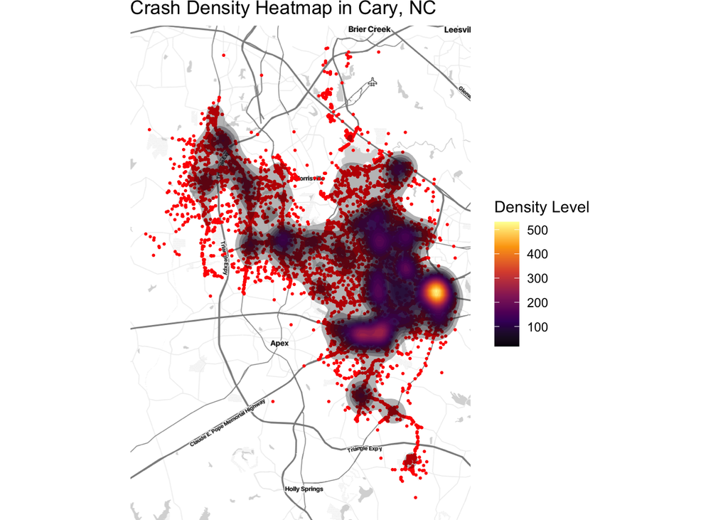

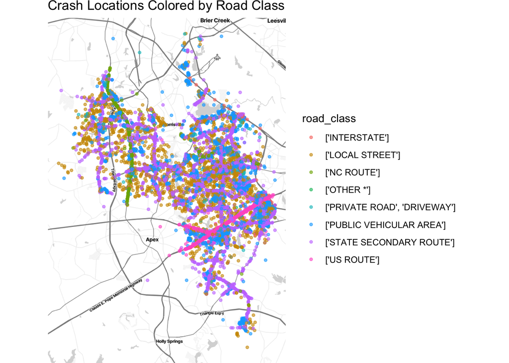

For our second research question, which explored crash frequency patterns at specific times of day, we supplemented the crash dataset with hourly traffic volume counts from the Town of Cary’s Traffic Counts portal, North Carolina Department of Transportation (NCDOT) resources, and the Traffic Data Online portal. These secondary datasets provided detailed information on turning movements, vehicle classification, travel times, spot speeds, and traffic volumes. We filtered and matched traffic volume data geographically and temporally to crash locations, specifically focusing on the US-64 at US-1 Southbound On-Ramp hotspot. This additional traffic volume information, representing vehicle interaction instances at different times, allowed us to adjust crash likelihood for exposure — enabling comparisons of crash risk across hours of the day.

# RESULTS

To answer the first question, “How do roadway characteristics (such as road type, surface condition, and lighting) predict crash severity?”, we first modeled the binary severity classification, aiming to predict whether or not a crash would be “severe” (involving injury or a fatality) or “non-severe” (PDO only). We then modeled a numeric severity index calculated based on the number of injuries, fatalities, and the number of people involved, based on NCDOT guidelines. For both modeling tasks, we used roadway and environmental predictors including: road class, road surface, light condition, weather, and number of vehicles involved. We tested models using individual predictors, additive combinations of predictors, and interaction terms. We evaluated binary models using classification accuracy and AUC (area under the ROC curve), and continuous models using Mean Absolute Error (MAE) through 10-fold cross-validation.

Cross-Validated Accuracy for Models Predicting Binary Severity (Top 2 Highlighted in Red)

| Model | Accuracy |
| --- | --- |
| road_class only | 0.8654 |
| road_surface only | 0.8654 |
| light_condition only | 0.8654 |
| weather only | 0.8654 |
| num_vehicles only | 0.8658 |
| road_class + road_surface | 0.8654 |
| all additive | 0.8660 |
| road_class * light_condition | 0.8654 |

For the ROC curves for each individual model and our additive model, we also see that the full additive model was stronger than any individual predictor; however, road class and number of vehicles stood out among individual predictors. This suggests that the characteristic road class that includes designations such as interstate, local street, private road, were better predictors of crash severity than other variables.

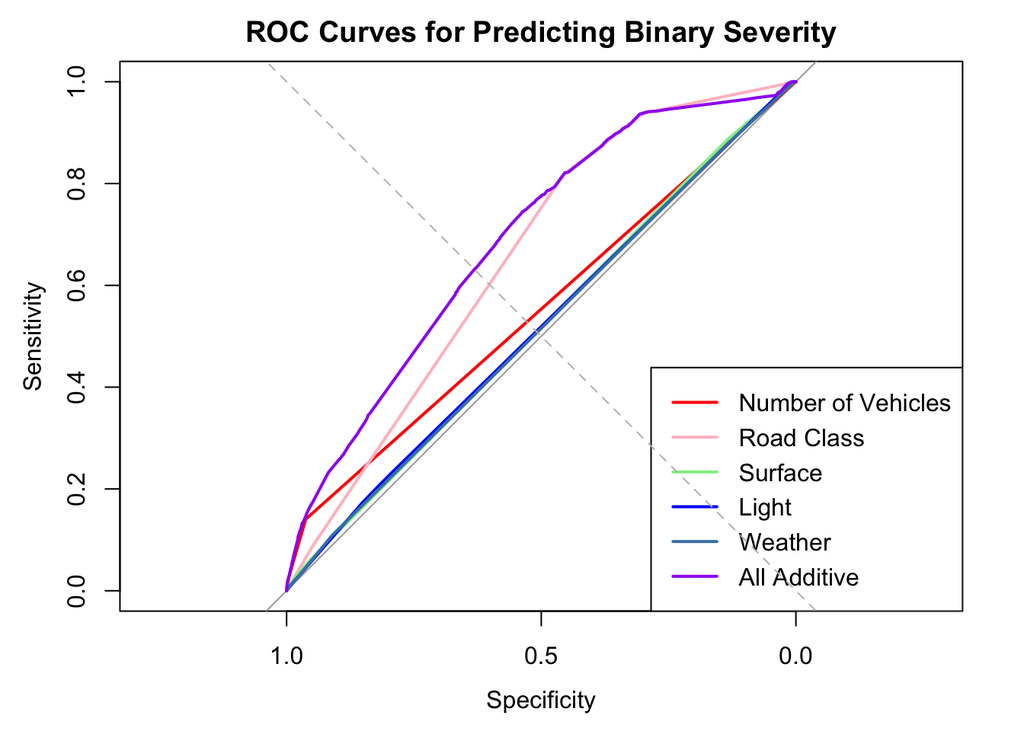

AUC Comparison for Predicting Binary Severity (Top 3 Highlighted)

| Predictor | AUC |
| --- | --- |
| Number of Vehicles | 0.5516 |
| Road Class | 0.6532 |
| Surface | 0.5162 |
| Light | 0.5166 |
| Weather | 0.5141 |
| All Additive | 0.6889 |

Model Performance Metrics

| True Positive | True Negative | False Positive | False Negative | Accuracy Rate | Error Rate |
| --- | --- | --- | --- | --- | --- |
| 22 | 19127 | 13 | 2954 | 0.8658 | 0.1342 |

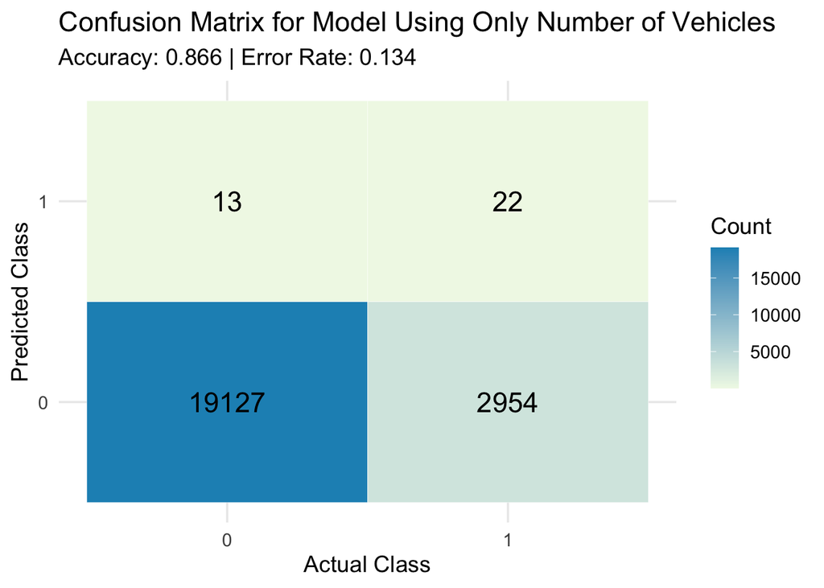

Model Comparison Using Alternate Severity Index (Top 4 Highlighted in Red, ‘road_class’ Underlined)

| Model2 | MAE |
| --- | --- |
| road_class only | 0.8768 |
| road_surface only | 0.9148 |
| light_condition only | 0.9149 |
| weather only | 0.9153 |
| num_vehicles only | 0.8866 |
| location only | 0.9159 |
| time and day only | 0.9158 |
| road_class + road_surface | 0.8766 |
| all additive | 0.8752 |
| road_class * light_condition | 0.8759 |

Our second research question was: “Are there specific times of day or days of the week with disproportionately high crash frequency, after accounting for traffic volume?” To investigate this, we focused on a subset of key variables: latitude and longitude to spatially isolate crashes near a hotspot, crash date and time to extract the crash hour, and traffic volume to normalize crash counts. We also classified crashes as either property damage only (PDO) or severe (involving injuries or fatalities). After identifying that the Town of Cary maintains public traffic count stations, we realized we could merge crash counts with corresponding traffic volumes. We focused on the single location with the highest number of crashes (latitude 35.738, longitude -78.7949) and filtered crashes occurring within 0.002 degrees (approximately 720 feet) of this hotspot.

```
##   latitude_secondary longitude_secondary  n
## 1             35.738            -78.7949 16
```

To estimate traffic exposure, we utilized turning movement count datasets collected by the Town of Cary at this intersection. These datasets recorded the number of vehicles entering and exiting the intersection in 15-minute intervals, across various dates and years. We grouped both crash counts and traffic volume by hour for comparison. To merge these datasets, we created a function to clean inconsistencies in the time formats and standardize hours into 24-hour blocks. Crash counts and traffic volumes were then aligned by hour, allowing us to calculate a crash likelihood metric: crash count / traffic volume per hour. We then plotted crash likelihood across the day to visualize patterns and identify time windows where crash risk appeared disproportionately high relative to traffic exposure.

While plotting raw crash likelihood provided initial insights, we sought a more formal method to account for the non-linear relationship between time of day, traffic volume, and crash frequency. First, we modeled traffic volume using a natural spline regression to capture typical traffic patterns, such as morning and evening rush hours. Next, we built a Poisson regression model to predict crash counts based on predicted traffic volume and crash hour, treating crash frequency as count data. In this model, traffic volume was not a statistically significant predictor after adjusting for time of day; however, time of day itself showed a strong, systematic effect. Specifically, crash risk was elevated during late morning and early afternoon (11 AM to 3 PM).

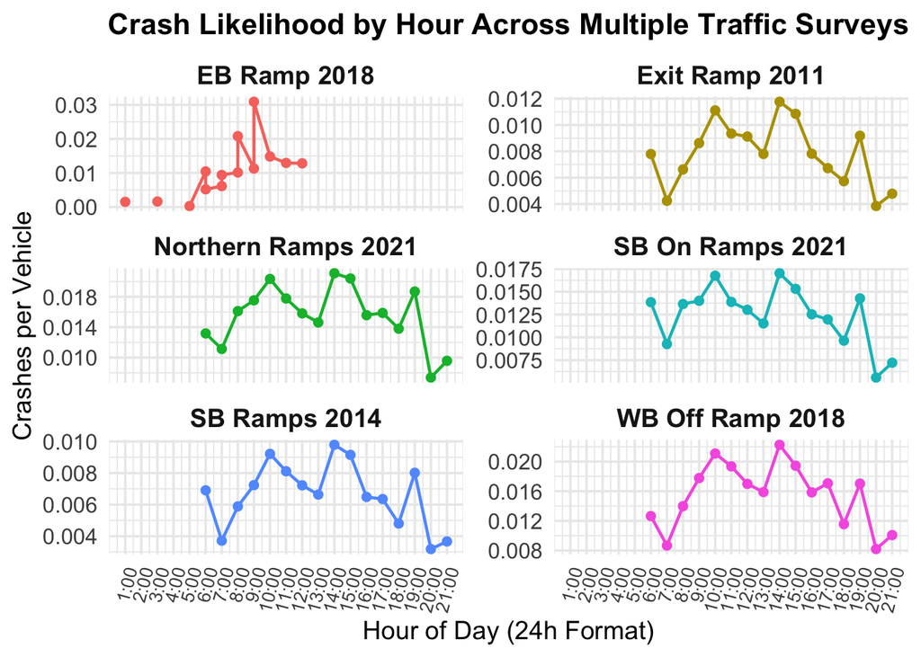

To allow for interactive exploration of crash likelihood by time of day across multiple traffic datasets, we developed a Shiny app. The app allows users to select different traffic surveys and filter crash likelihood patterns across hourly ranges.

You can view and interact with the app at the following link:  
[Click to open the Crash Likelihood Explorer App](https://nq5ftb-maria-hromcenco.shinyapps.io/traffic_crash_likelihood_app/)

Using the model outputs, we calculated an adjusted crash risk per 1,000 vehicles for each hour, standardizing crash risk across different traffic volumes. Visualizing these results, we observed that although both morning and evening rush hours had high traffic volumes, the morning rush exhibited a higher crash risk. This suggests behavioral or environmental factors may contribute more heavily to crash risk earlier in the day. To further validate our findings, we plotted the proportion of severe crashes by crash hour using our binary classification metric, revealing that earlier hours also had a higher proportion of severe outcomes.

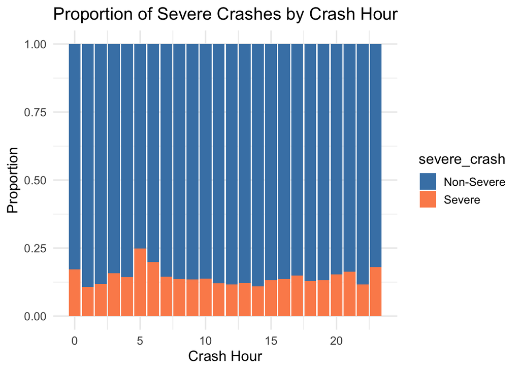

To test the generalizability of our approach, we repeated the analysis at a second location: Walnut Street and Meeting Street. Using crash data and traffic volume files from 2012 and 2018, we applied the same filtering, crash likelihood calculation, severity categorization, and Poisson modeling procedures. The model achieved a mean absolute error (MAE) of 3.94 and a root mean squared error (RMSE) of 5.04, suggesting reasonable predictive performance when modeling crash frequency based on traffic volume and time of day at a new location.

Comparison of Actual vs Predicted Traffic Volume, Crash Frequency, and Risk at Walnut @ Meeting St

| hour_start_24 | traffic_volume | predicted_traffic_volume | num_crashes | predicted_num_crashes | crash_likelihood | predicted_crash_likelihood |
| --- | --- | --- | --- | --- | --- | --- |
| 1 | 1492 | 2648.18 | 4 | 4.00 | 2.68 | 1.51 |
| 2 | 1130 | 2845.99 | 2 | 0.00 | 1.77 | 0.00 |
| 3 | 911 | 3019.47 | 1 | 5.12 | 1.10 | 1.69 |
| 4 | 836 | 3144.27 | 2 | 0.00 | 2.39 | 0.00 |
| 5 | 1143 | 3196.05 | 2 | 1.17 | 1.75 | 0.37 |
| 6 | 1431 | 3150.47 | 0 | 9.66 | 0.00 | 3.07 |
| 7 | 2141 | 2998.13 | 7 | 23.17 | 3.27 | 7.73 |
| 8 | 2814 | 2789.37 | 7 | 43.53 | 2.49 | 15.61 |
| 9 | 3493 | 2589.46 | 22 | 29.74 | 6.30 | 11.48 |
| 10 | 4213 | 2463.66 | 19 | 33.10 | 4.51 | 13.44 |
| 11 | 4875 | 2477.26 | 28 | 33.50 | 5.74 | 13.52 |
| 12 | 5030 | 2668.84 | 44 | 35.80 | 8.75 | 13.42 |
| 13 | 4905 | 2970.29 | 57 | 28.06 | 11.62 | 9.45 |
| 14 | 5013 | 3286.84 | 54 | 35.54 | 10.77 | 10.81 |
| 15 | 4584 | 3523.69 | 54 | 37.50 | 11.78 | 10.64 |
| 16 | 4410 | 3586.05 | 41 | 39.92 | 9.30 | 11.13 |
| 17 | 4288 | 3403.92 | 38 | 51.72 | 8.86 | 15.20 |
| 18 | 3881 | 3006.37 | 33 | 24.84 | 8.50 | 8.26 |
| 19 | 3295 | 2447.25 | 33 | 23.37 | 10.02 | 9.55 |
| 20 | 2344 | 1780.43 | 19 | 7.53 | 8.11 | 4.23 |
| 21 | 1705 | 1059.75 | 15 | 7.25 | 8.80 | 6.84 |
| 22 | 1157 | 330.10 | 8 | NA | 6.91 | NA |
| 23 | 551 | -399.55 | 4 | NA | 7.26 | NA |
| 0 | 1647 | 2446.30 | 4 | NA | 2.43 | NA |
| 6 | 931 | 3150.47 | 0 | 9.66 | 0.00 | 3.07 |
| 7 | 2335 | 2998.13 | 7 | 23.17 | 3.00 | 7.73 |
| 8 | 2706 | 2789.37 | 7 | 43.53 | 2.59 | 15.61 |
| 9 | 2488 | 2589.46 | 22 | 29.74 | 8.84 | 11.48 |
| 10 | 2409 | 2463.66 | 19 | 33.10 | 7.89 | 13.44 |
| 11 | 2916 | 2477.26 | 28 | 33.50 | 9.60 | 13.52 |
| 12 | 3611 | 2668.84 | 44 | 35.80 | 12.18 | 13.42 |
| 13 | 3450 | 2970.29 | 57 | 28.06 | 16.52 | 9.45 |
| 14 | 3204 | 3286.84 | 54 | 35.54 | 16.85 | 10.81 |
| 15 | 3460 | 3523.69 | 54 | 37.50 | 15.61 | 10.64 |
| 16 | 3780 | 3586.05 | 41 | 39.92 | 10.85 | 11.13 |
| 17 | 4050 | 3403.92 | 38 | 51.72 | 9.38 | 15.20 |
| 18 | 3543 | 3006.37 | 33 | 24.84 | 9.31 | 8.26 |
| 19 | 2634 | 2447.25 | 33 | 23.37 | 12.53 | 9.55 |
| 20 | 1958 | 1780.43 | 19 | 7.53 | 9.70 | 4.23 |
| 21 | 1227 | 1059.75 | 15 | 7.25 | 12.22 | 6.84 |

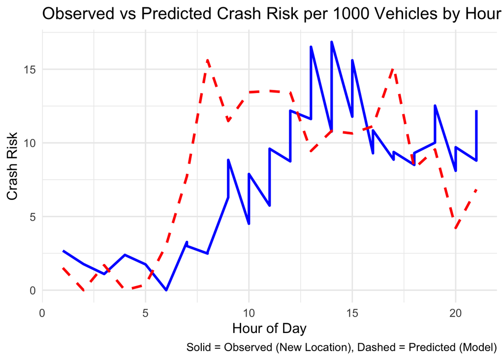

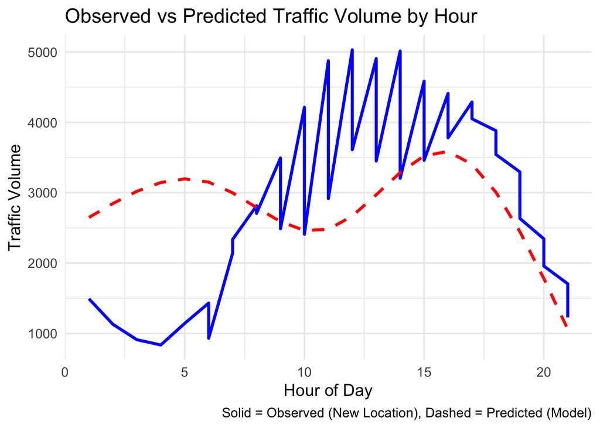

Prediction Accuracy Metrics for Crash Risk (New Location)

| Model | MAE | RMSE |
| --- | --- | --- |
| Crash Risk Prediction | 3.94 | 5.04 |

One important limitation we observed throughout the analysis was the low number of crashes during certain hours, particularly late at night and early morning. These small hourly crash counts introduced noise into our crash likelihood estimates, making predictions for these times less stable.